# individual1.Rmd

xiwang

02/19/19

## Open file

```r
HAPPY <- readRDS("HAPPY.rds")
dim (HAPPY)
```

```
## [1] 62466    11
```

# Data Cleaning

## Data clean 1: replace missing value “IAP,”DK" and “NA” to NA

```r
HAPPY[is.na(HAPPY)] <- NA
HAPPY[HAPPY == "NA"] <- NA
HAPPY[HAPPY == "IAP"] <- NA
HAPPY[HAPPY == "DK"] <- NA
```

## Data clean 2: Check the type of the variable and cast into the right type

##### After the data clean, the AGE variable shows as numeric.

```r
HAPPY$AGE[HAPPY$AGE == "89 OR OLDER"] <- 89
HAPPY$AGE <- as.numeric (HAPPY$AGE)
is.numeric (HAPPY$AGE)
```

```
## [1] TRUE
```

```r
str (HAPPY)
```

```
## 'data.frame':    62466 obs. of  11 variables:
##  $ HAPPY   : chr  "NOT TOO HAPPY" "NOT TOO HAPPY" "PRETTY HAPPY" "NOT TOO HAPPY" ...
##  $ YEAR    : int  1972 1972 1972 1972 1972 1972 1972 1972 1972 1972 ...
##  $ AGE     : num  23 70 48 27 61 26 28 27 21 30 ...
##  $ SEX     : chr  "FEMALE" "MALE" "FEMALE" "FEMALE" ...
##  $ MARITAL : chr  "NEVER MARRIED" "MARRIED" "MARRIED" "MARRIED" ...
##  $ DEGREE  : chr  "BACHELOR" "LT HIGH SCHOOL" "HIGH SCHOOL" "BACHELOR" ...
##  $ FINRELA : chr  "AVERAGE" "ABOVE AVERAGE" "AVERAGE" "AVERAGE" ...
##  $ HEALTH  : chr  "GOOD" "FAIR" "EXCELLENT" "GOOD" ...
##  $ WTSSALL : num  0.445 0.889 0.889 0.889 0.889 ...
##  $ PARTYID : chr  "IND,NEAR DEM" "NOT STR DEMOCRAT" "INDEPENDENT" "NOT STR DEMOCRAT" ...
##  $ POLVIEWS: chr  NA NA NA NA ...
```

## Data clean 3: Bring all levels of factors into a sensible order based on MARITAL and AGE

```r
HAPPY <- HAPPY[order(HAPPY$MARITAL, HAPPY$AGE),]
head (HAPPY, 20)
```

```
##               HAPPY YEAR AGE    SEX  MARITAL         DEGREE
## 36332  PRETTY HAPPY 1998  18   MALE DIVORCED LT HIGH SCHOOL
## 2783  NOT TOO HAPPY 1973  19 FEMALE DIVORCED LT HIGH SCHOOL
## 5536     VERY HAPPY 1975  19   MALE DIVORCED    HIGH SCHOOL
## 11845    VERY HAPPY 1980  19 FEMALE DIVORCED LT HIGH SCHOOL
## 38876 NOT TOO HAPPY 2000  19   MALE DIVORCED LT HIGH SCHOOL
## 41122          <NA> 2002  19 FEMALE DIVORCED LT HIGH SCHOOL
## 49478          <NA> 2006  19 FEMALE DIVORCED LT HIGH SCHOOL
## 1694   PRETTY HAPPY 1973  20   MALE DIVORCED LT HIGH SCHOOL
## 2909  NOT TOO HAPPY 1973  20 FEMALE DIVORCED    HIGH SCHOOL
## 6539     VERY HAPPY 1976  20 FEMALE DIVORCED    HIGH SCHOOL
## 17735    VERY HAPPY 1985  20 FEMALE DIVORCED    HIGH SCHOOL
## 19165  PRETTY HAPPY 1986  20 FEMALE DIVORCED LT HIGH SCHOOL
## 39709 NOT TOO HAPPY 2000  20   MALE DIVORCED    HIGH SCHOOL
## 59456  PRETTY HAPPY 2014  20   MALE DIVORCED    HIGH SCHOOL
```

[output cut: 48 more lines]

# Data Exploration

## Data Eploration 1: Investigate the distributions of 2 different variables.

```r
# Remove missing value in the data frame
HAPPY <- na.omit (HAPPY)
dim (HAPPY)
```

```
## [1] 37296    11
```

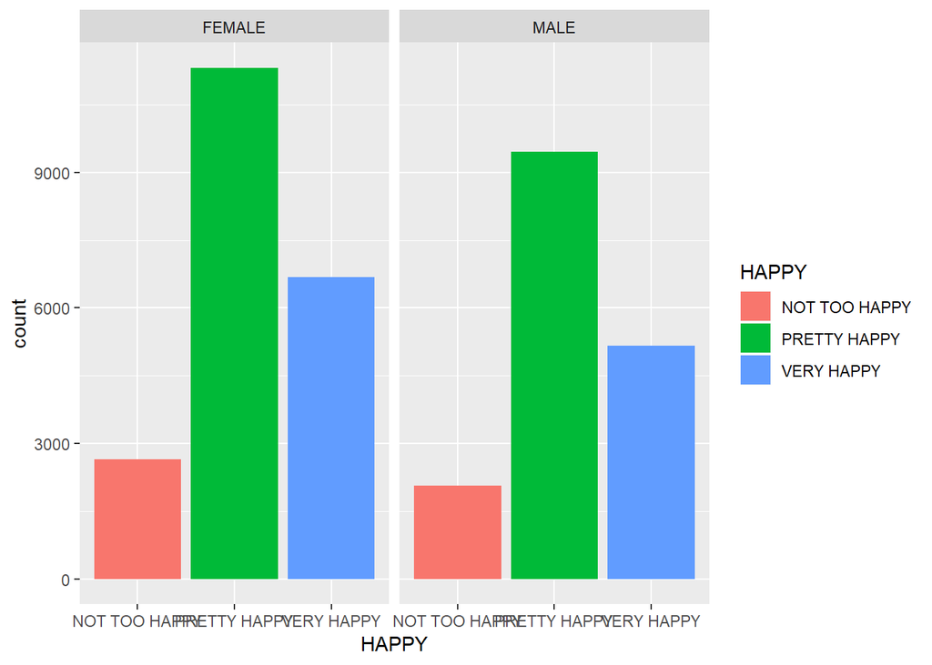

```r
# Explore the dataset
library (ggplot2)
# Check the distribution of variable: HAPPY based on age
ggplot (HAPPY, aes(x=HAPPY, fill= HAPPY)) + geom_bar() + facet_grid(~SEX, scales="free_y")
```

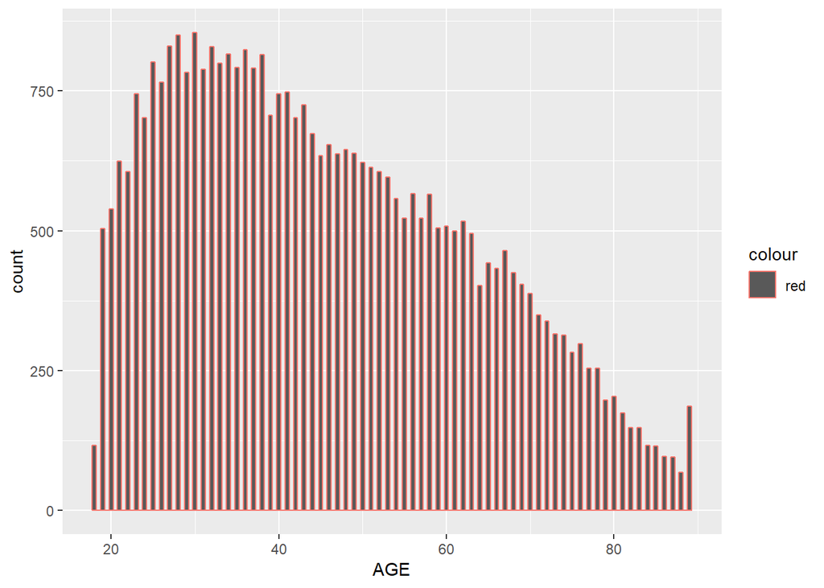

```r
# Check the distribution of variable: AGE
ggplot (HAPPY, aes(x=AGE, color= "red")) + geom_histogram (position = "stack" , binwidth = .5)
```

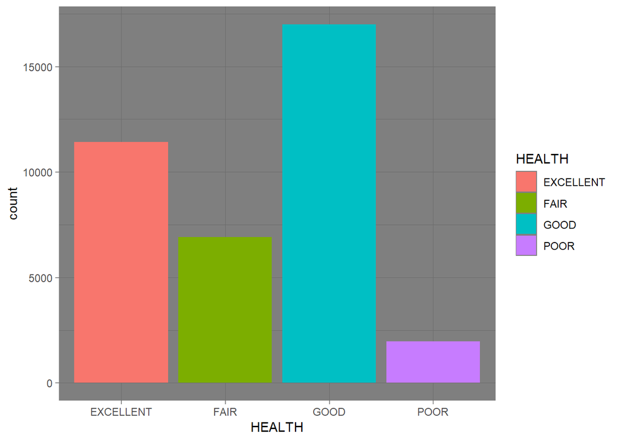

```r
# Check the distribution of variable HEALTH:
ggplot (HAPPY, aes(x=HEALTH, fill=HEALTH)) + geom_bar() + theme_dark(base_size = 11, base_family = "")
```

## Data Eploration 2: Investigate the relationship between happiness and three other variables in the data.

```r
library(ggmosaic)
head (HAPPY)
```

```
##               HAPPY YEAR AGE    SEX  MARITAL         DEGREE       FINRELA
## 5536     VERY HAPPY 1975  19   MALE DIVORCED    HIGH SCHOOL ABOVE AVERAGE
## 11845    VERY HAPPY 1980  19 FEMALE DIVORCED LT HIGH SCHOOL BELOW AVERAGE
## 38876 NOT TOO HAPPY 2000  19   MALE DIVORCED LT HIGH SCHOOL BELOW AVERAGE
## 6539     VERY HAPPY 1976  20 FEMALE DIVORCED    HIGH SCHOOL       AVERAGE
## 17735    VERY HAPPY 1985  20 FEMALE DIVORCED    HIGH SCHOOL BELOW AVERAGE
## 39709 NOT TOO HAPPY 2000  20   MALE DIVORCED    HIGH SCHOOL BELOW AVERAGE
##       HEALTH WTSSALL         PARTYID             POLVIEWS
## 5536    FAIR  1.3979 STRONG DEMOCRAT SLGHTLY CONSERVATIVE
## 11845   FAIR  1.0225     INDEPENDENT     SLIGHTLY LIBERAL
## 38876   GOOD  1.0985     INDEPENDENT              LIBERAL
## 6539    GOOD  0.9709 STRONG DEMOCRAT              LIBERAL
## 17735   GOOD  0.5181    IND,NEAR REP             MODERATE
## 39709   GOOD  0.5493    IND,NEAR DEM             MODERATE
```

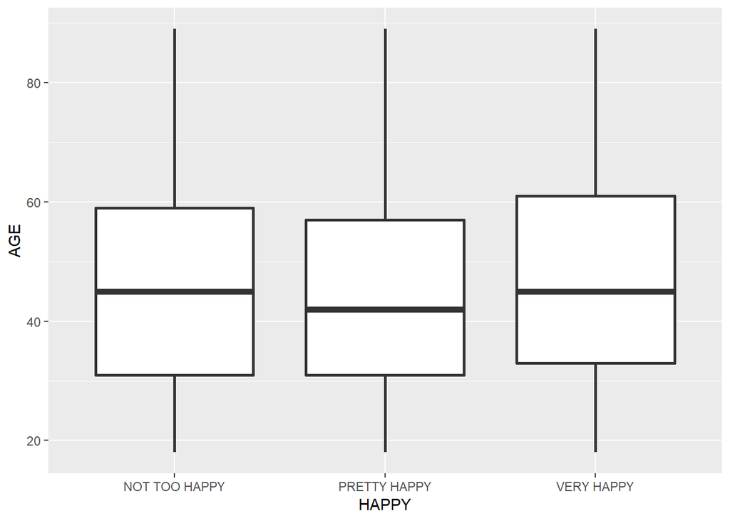

```r
# Relationship between HAPPY to AGE
ggplot (HAPPY, aes(x=HAPPY, y=AGE)) + geom_boxplot(size=1)
```

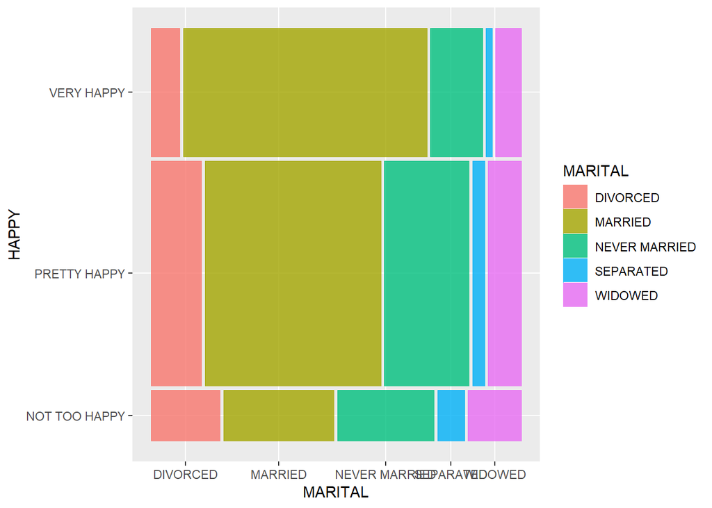

```r
# Relationship between HAPPY to MARITAL
ggplot(data = HAPPY)  +
  geom_mosaic(aes(x = product(HAPPY), fill=MARITAL))  + ylab ("MARITAL") + xlab ("HAPPY") + coord_flip()
```

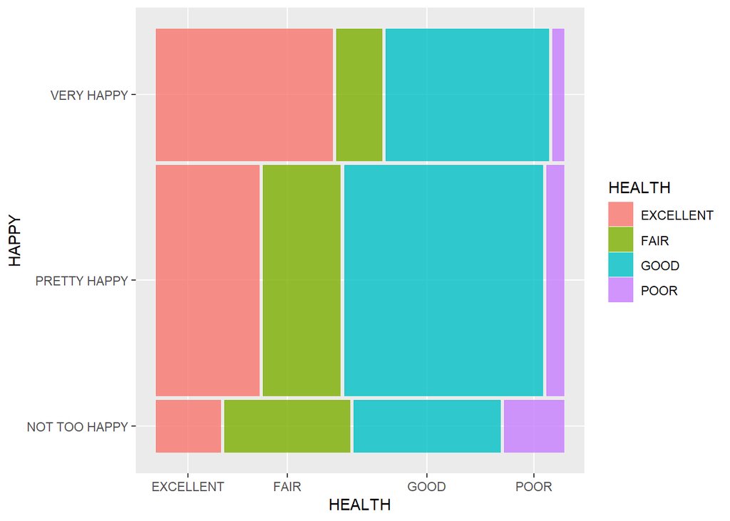

```r
# Relationship between HAPPY to MARITAL
ggplot(data = HAPPY)  +
  geom_mosaic(aes(x = product(HAPPY), fill=HEALTH)) + ylab ("HEALTH") + xlab ("HAPPY") + coord_flip()
```

## Data Eploration 3: What do you learn from the data set? Write one or two paragraphs to describe.

##### 1. First, there are so many missing value in this dataset, after cleaning it, almost half of the data were removed.

##### 2. In terms of the variable HAPPY, there are more people reported they are in Pretty happy and Very happy conditions.

##### 3. There is a right skewed distribution of participant AGE in this dataset.

##### 4. In terms of the variable HEALTH, there are more people reported they are in Excellent and Good conditions.

##### 5. From the boxplot, there is no significant difference can bd identified between the AGE and HAPPY.

##### 6. There are more participants are in a Married status, and those people are have higher percentages in both Very Happy and Pretty Happy conditions.

##### 7. Both Divorced and Widowed particpants showed a large percentages of Not too Happy than other people.

##### 8. Participants in a very Excellent health contion shows a larger percent of Very Happy than other groups, while participants in a Poor health contion shows a larger percentage of Not too Happy than other groups.